# P5

2023-09-23

```r
set.seed(042)
```

## Data

```r
str(data)
```

```
## 'data.frame':    241 obs. of  2 variables:
##  $ bulan  : int  1 2 3 4 5 6 7 8 9 10 ...
##  $ Inflasi: int  29 27 28 25 22 22 17 22 27 28 ...
```

```r
stas <- data
stat
```

```
## function (x)
## {
##     x
## }
## <bytecode: 0x00000215184ccc68>
## <environment: namespace:ggplot2>
```

```r
stas <- ts(data$Inflasi)
```

### Plot *Time Series*

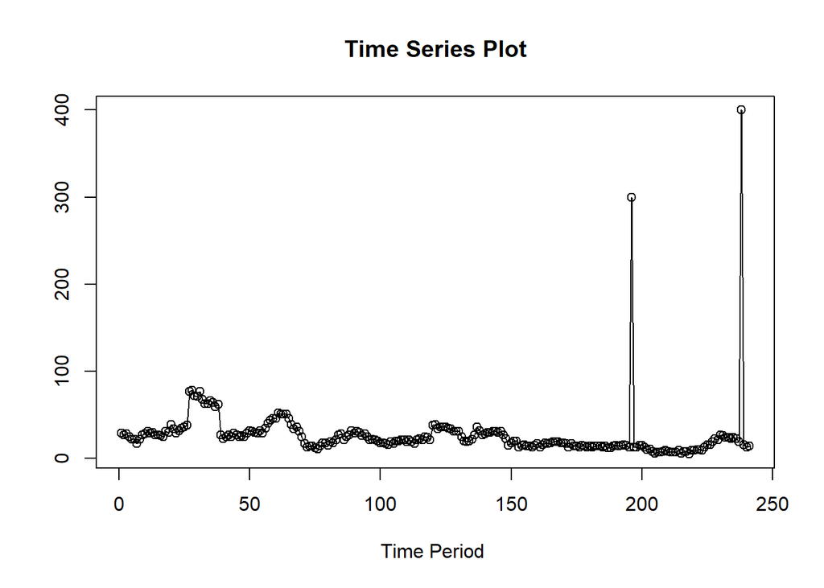

```r
library(ggplot2)
plot_stas <- ts.plot(stas, xlab="Time Period ", ylab="",
        main = "Time Series Plot")
points(stas)
```

Plot deret waktu di atas menunjukkan bahwa data cenderung membuat grafik tren, dan tidak stasioner dalam rataan.

### Plot ACF

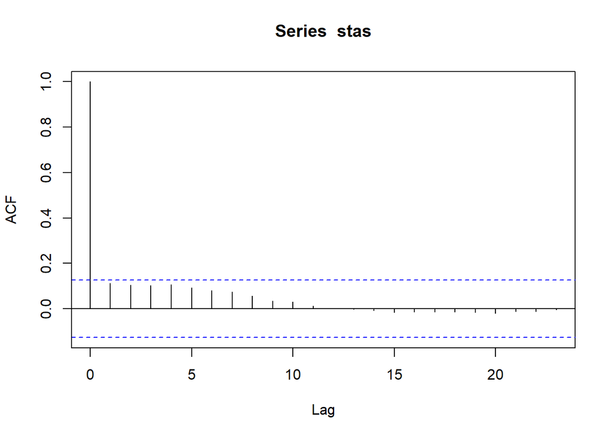

```r
acf(stas)
```

### Uji ADF

```r
tseries::adf.test(stas)
```

```
##
##  Augmented Dickey-Fuller Test
##
## data:  stas
## Dickey-Fuller = -3.4014, Lag order = 6, p-value = 0.05499
## alternative hypothesis: stationary
```

$H_0$ : Data tidak stasioner dalam rataan

$H_1$ : Data stasioner dalam rataan

### Plot Box-Cox

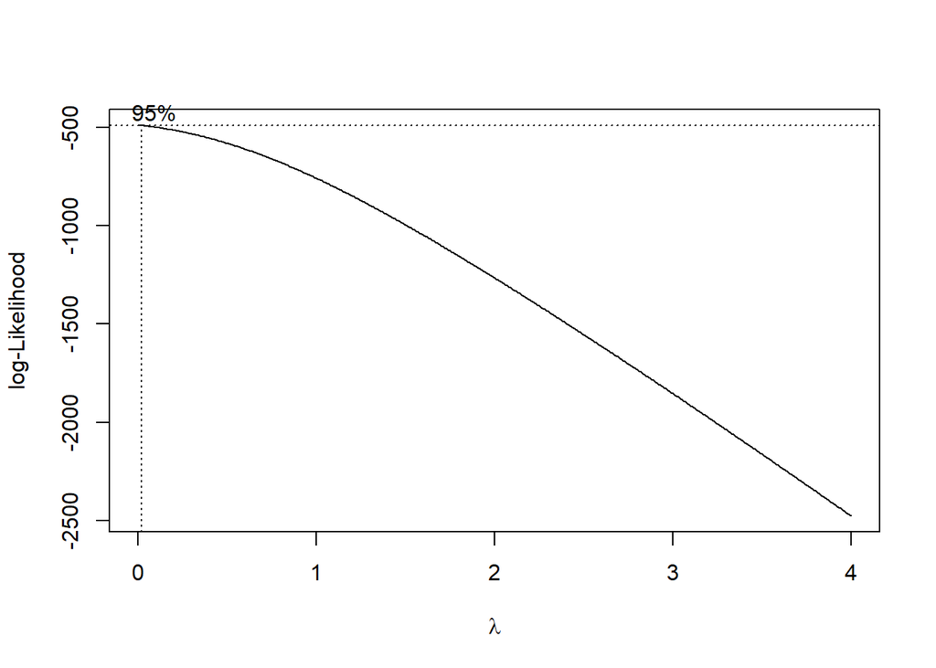

```r
index <- seq(1:241)
bc = boxcox(stas~index, lambda = seq(0,4,by=0.01))
```

```r
#Nilai Rounded Lambda
lambda <- bc$x[which.max(bc$y)]
lambda
```

```
## [1] 0
```

```r
#SK
bc$x[bc$y > max(bc$y) - 1/2 * qchisq(.95,1)]
```

```
## [1] 0.00 0.01
```

Gambar di atas menunjukkan nilai *rounded value* ($\lambda$) optimum sebesar **0** dan pada selang kepercayaan 95% nilai memiliki batas bawah **0,00** dan batas atas **0.01**. Selang tersebut tidak memuat nilai satu sehingga dapat dikatakan bahwa data tersebut tidak stasioner dalam ragam.

### Partisi Data

#### Bagian 1

```r
dt_stas1 <- stas[1:(length(data$bulan)/2)] |> ts()
mean(dt_stas1)
```

```
## [1] 30.975
```

```r
var(dt_stas1)
```

```
## [1] 230.6128
```

#### Plot Time Series

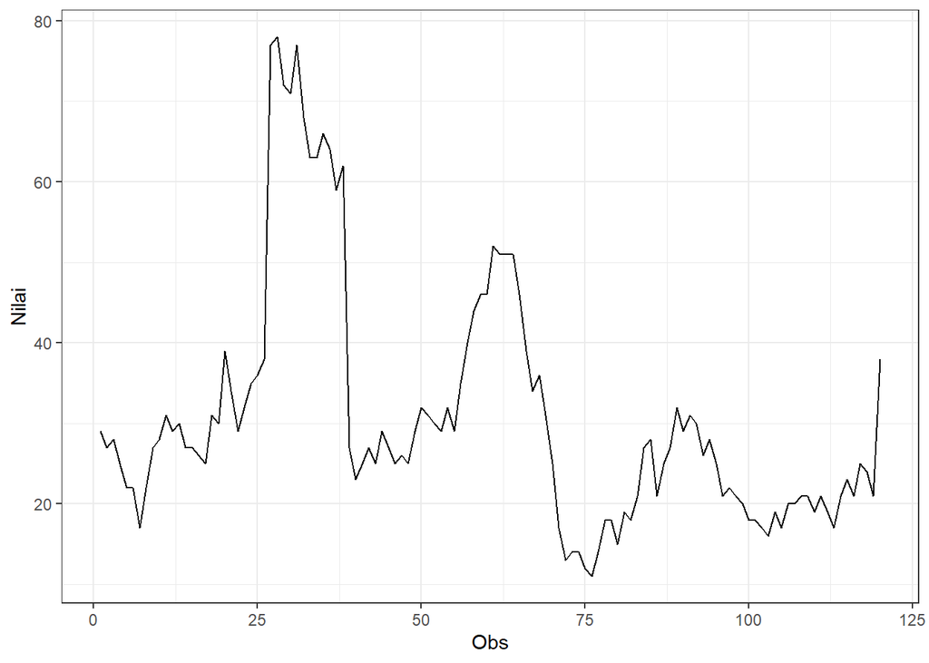

```r
dt_stas1 |> as_tsibble() |>
  ggplot(aes(x = index, y = value)) +
  geom_line() + theme_bw() +
  xlab("Obs") + ylab("Nilai")
```

Plot deret waktu di atas menunjukkan bahwa data tidak stasioner dalam rataan, ditandai dengan data yang tidak menyebar di sekitar nilai tengahnya

#### Plot ACF

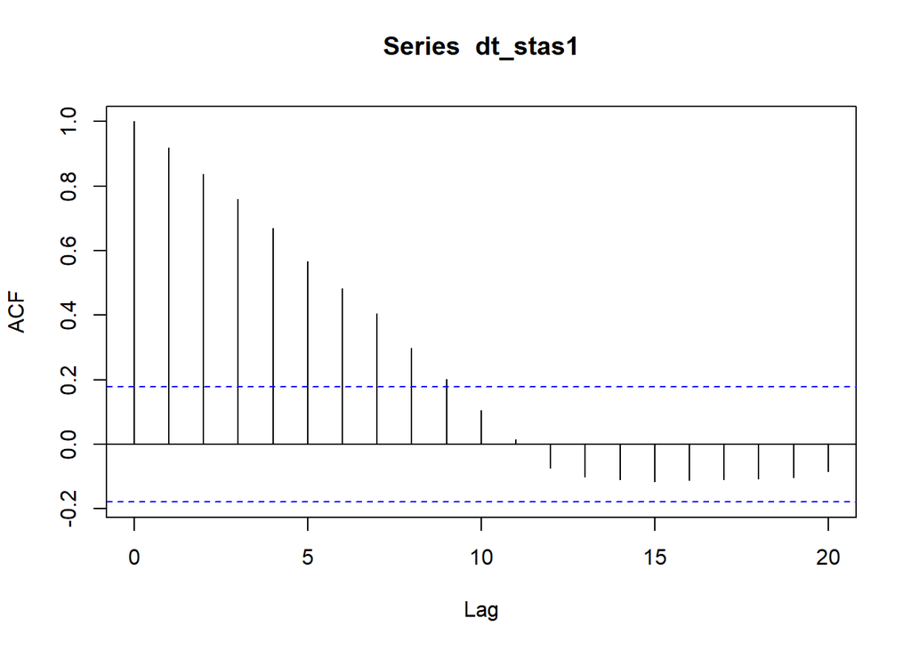

```r
acf(dt_stas1)
```

Berdasarkan plot ACF, terlihat bahwa plot ACF pada data tersebut cenderung *tails off* dan membentuk grafik cosinus. Berarti, belum stastioner.

#### Uji ADF

```r
tseries::adf.test(dt_stas1)
```

```
##
##  Augmented Dickey-Fuller Test
##
## data:  dt_stas1
## Dickey-Fuller = -3.1451, Lag order = 4, p-value = 0.101
## alternative hypothesis: stationary
```

$H_0$ : Data tidak stasioner dalam rataan

$H_1$ : Data stasioner dalam rataan

Berdasarkan uji ADF tersebut, didapat *p-value* sebesar 0.101 yang lebih besar dari taraf nyata 5% sehingga tak tolak $H_0$ dan menandakan bahwa data tidak stasioner dalam rataan. Hal ini sesuai dengan hasil eksplorasi menggunakan plot time series dan plot ACF.

#### Plot Boxcox

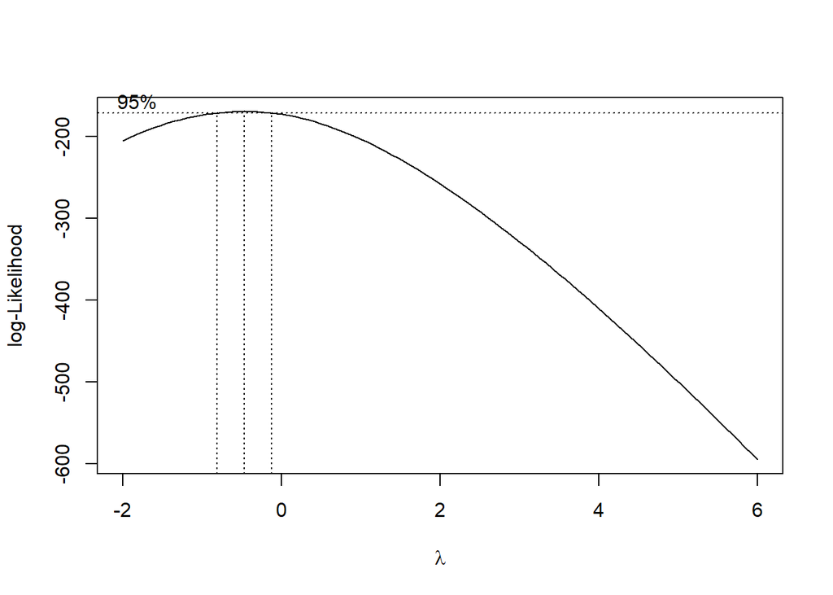

```r
index <- seq(1:(length(data$bulan)/2))
bc = boxcox(dt_stas1~index, lambda = seq(-2,6,by=1))
```

```r
#Nilai Rounded Lambda
lambda <- bc$x[which.max(bc$y)]
lambda
```

```
## [1] -0.4646465
```

```r
#SK
bc$x[bc$y > max(bc$y) - 1/2 * qchisq(.95,1)]
```

```
## [1] -0.7878788 -0.7070707 -0.6262626 -0.5454545 -0.4646465 -0.3838384 -0.3030303
## [8] -0.2222222 -0.1414141
```

Gambar di atas menunjukkan nilai *rounded value* ($\lambda$) optimum sebesar **-0.4646465** dan pada selang kepercayaan 95% nilai memiliki batas bawah **-0,787** dan batas atas -**0.141**. Selang tersebut tidak memuat nilai satu sehingga dapat dikatakan bahwa data tidak stasioner dalam ragam.

#### Bagian 2

```r
dt_stas2 <- stas[1:160] |> ts()
mean(dt_stas2)
```

```
## [1] 29.61875
```

```r
var(dt_stas2)
```

```
## [1] 193.6462
```

#### Plot Time Series

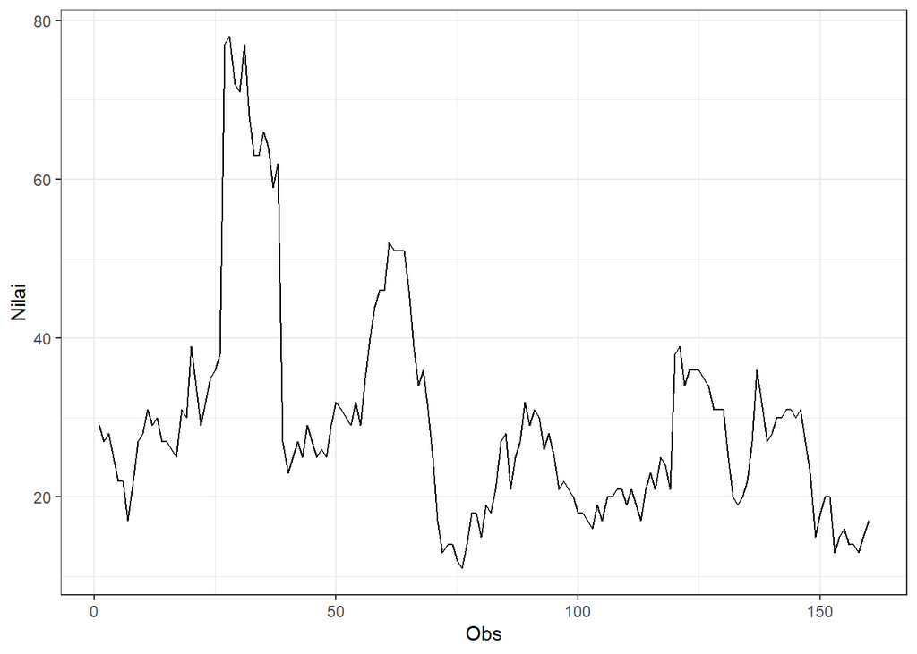

```r
dt_stas2 |> as_tsibble() |>
  ggplot(aes(x = index, y = value)) +
  geom_line() + theme_bw() +
  xlab("Obs") + ylab("Nilai")
```

#### Plot ACF

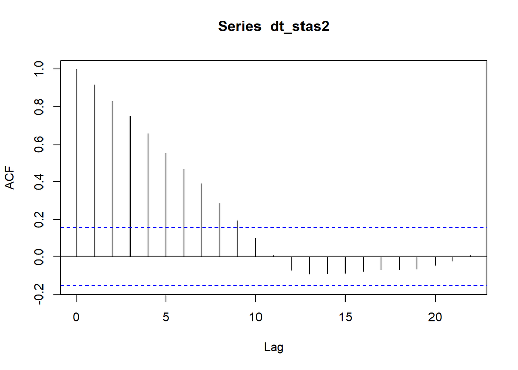

```r
acf(dt_stas2)
```

Berdasarkan plot ACF, terlihat bahwa plot ACF pada data tersebut cenderung tails off. Berarti, belum stasioner.

#### Uji ADF

```r
adf.test(dt_stas2)
```

```
##
##  Augmented Dickey-Fuller Test
##
## data:  dt_stas2
## Dickey-Fuller = -3.3629, Lag order = 5, p-value = 0.06321
## alternative hypothesis: stationary
```

$H_0$ : Data tidak stasioner dalam rataan

$H_1$ : Data stasioner dalam rataan

Berdasarkan uji ADF tersebut, didapat *p-value* sebesar 0.06 yang lebih besar dari taraf nyata 5% sehingga tak tolak $H_0$ dan menandakan bahwa data tidak stasioner dalam rataan. Hal ini sesuai dengan hasil eksplorasi menggunakan plot time series dan plot ACF.

#### Plot Boxcox

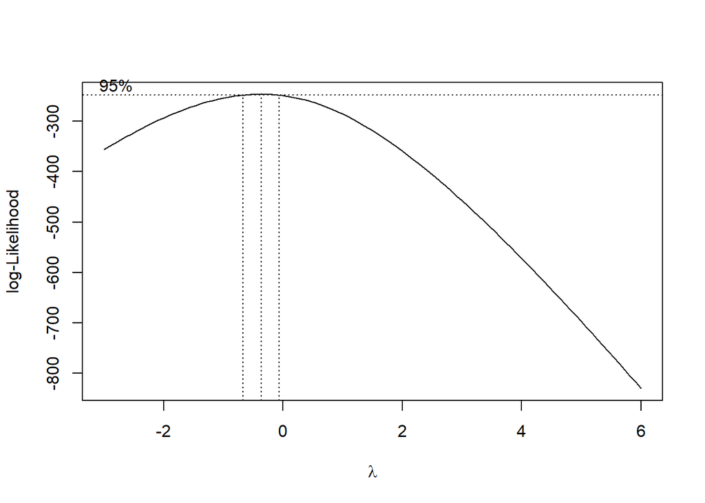

```r
index <- seq(1:160)
bc = boxcox(dt_stas2~index, lambda = seq(-3,6,by=1))
```

```r
#Nilai Rounded Lambda
lambda <- bc$x[which.max(bc$y)]
lambda
```

```
## [1] -0.3636364
```

```r
#SK
bc$x[bc$y > max(bc$y) - 1/2 * qchisq(.95,1)]
```

```
## [1] -0.63636364 -0.54545455 -0.45454545 -0.36363636 -0.27272727 -0.18181818
## [7] -0.09090909
```